# Dublin House Prices

## Dublin House Prices from 2010

Since 2010 Ireland’s house property prices have been registered at propertypriceregister.ie. This sample code downloads the house prices and stores as a tibble.

```r
library(readr)
library(dplyr)
library(scales)
library(zoo)
library(lubridate)
library(ggplot2)
```

Download the zip file from https://www.propertypriceregister.ie.

```r
if (!file.exists("PPR-ALL.zip") ||
    file.mtime("PPR-ALL.zip") < Sys.Date())
  {download.file(PriceUrl, "PPR-ALL.zip")}
```

Use the `read_csv` function in `readr` to read in the resulting CSV file PPR-All.csv and save as a tibble PPReg.

```r
PPReg <- readr::read_csv(unzip("PPR-ALL.zip", "PPR-ALL.csv"), col_names= c("Date_Of_Sale","Address","County","Eircode","Price","Not_Full_Market_Price","VAT_Exclusive","Description","Size"), col_types = c("c","c","c","c","c","c","c","c","c"),
                  skip=1,locale=locale(encoding = "UTF-8"))

head(PPReg)
```

```
## # A tibble: 6 × 9
##   Date_Of_Sale Address        County Eircode Price Not_F…¹ VAT_E…² Descr…³ Size
##   <chr>        <chr>          <chr>  <chr>   <chr> <chr>   <chr>   <chr>   <chr>
## 1 01/01/2010   5 Braemor Dri… Dublin <NA>    "\x8… No      No      Second… <NA>
## 2 03/01/2010   134 Ashewood … Laois  <NA>    "\x8… No      Yes     New Dw… grea…
## 3 04/01/2010   1 Meadow Aven… Dublin <NA>    "\x8… No      No      Second… <NA>
## 4 04/01/2010   1 The Haven, … Meath  <NA>    "\x8… No      No      Second… <NA>
## 5 04/01/2010   11 Melville H… Kilke… <NA>    "\x8… No      No      Second… <NA>
## 6 04/01/2010   12 Sallymount… Dublin <NA>    "\x8… No      No      Second… <NA>
## # … with abbreviated variable names ¹Not_Full_Market_Price, ²VAT_Exclusive,
## #   ³Description
```

All of the data types have been imported as character to avoid conversion issues. First convert Date_Of_Sale to a date format using the `as.Date` function. Then convert the price from a character to a number, first the number is *cleaned* by running the `sub('<80>','',)` function to remove the euro symbol and `gsub(',','')` to remove the commas, then the `as.numeric` function is run.

```r
PPReg <- PPReg %>%
         dplyr::mutate(Date_Of_Sale = as.Date(Date_Of_Sale, "%d/%m/%Y") ) %>%
         dplyr::mutate(Price = (as.numeric(gsub(',', '', sub('<80>', '', Price)))) )

head(PPReg)
```

```
## # A tibble: 6 × 9
##   Date_Of_Sale Address       County Eircode  Price Not_F…¹ VAT_E…² Descr…³ Size
##   <date>       <chr>         <chr>  <chr>    <dbl> <chr>   <chr>   <chr>   <chr>
## 1 2010-01-01   5 Braemor Dr… Dublin <NA>    343000 No      No      Second… <NA>
## 2 2010-01-03   134 Ashewood… Laois  <NA>    185000 No      Yes     New Dw… grea…
## 3 2010-01-04   1 Meadow Ave… Dublin <NA>    438500 No      No      Second… <NA>
## 4 2010-01-04   1 The Haven,… Meath  <NA>    400000 No      No      Second… <NA>
## 5 2010-01-04   11 Melville … Kilke… <NA>    160000 No      No      Second… <NA>
## 6 2010-01-04   12 Sallymoun… Dublin <NA>    425000 No      No      Second… <NA>
## # … with abbreviated variable names ¹Not_Full_Market_Price, ²VAT_Exclusive,
## #   ³Description
```

```r
filter(PPReg, grepl("CNOC SION, DROMCHONRACH|ATTRIORY, CARRICK ON SHANNON|Treagh, Inniskeen|AONGHUS ROAD, TALLAGHT", Address ) )
```

```
## # A tibble: 5 × 9
##   Date_Of_Sale Address       County Eircode  Price Not_F…¹ VAT_E…² Descr…³ Size
##   <date>       <chr>         <chr>  <chr>    <dbl> <chr>   <chr>   <chr>   <chr>
## 1 2010-01-08   "14 ST. AONG… Dublin <NA>    220000 No      No      Second… <NA>
## 2 2010-01-11   "Farmlands, … Louth  <NA>    255000 No      No      Second… <NA>
## 3 2014-10-31   "9 B\xd3THAR… Dublin <NA>    597000 No      No      Second… <NA>
## 4 2015-02-06   "21 D\xdaN R… Leitr… <NA>    140000 No      No      Second… <NA>
## 5 2015-02-24   "36 DUN RI, … Leitr… <NA>    155000 No      No      Second… <NA>
## # … with abbreviated variable names ¹Not_Full_Market_Price, ²VAT_Exclusive,
## #   ³Description
```

Replace the Irish accented letters with non accented letters and remove the trailing period at the end of some addresses.

```r
PPReg <- PPReg %>%
          dplyr::mutate(Address = gsub('<e1>', 'a', Address)) %>%
          dplyr::mutate(Address = gsub('<c1>', 'A', Address))%>%
          dplyr::mutate(Address = gsub('<e9>', 'e', Address)) %>%
          dplyr::mutate(Address = gsub('<c9>', 'E', Address)) %>%
          dplyr::mutate(Address = gsub('<ed>', 'i', Address)) %>%
          dplyr::mutate(Address = gsub('<cd>', 'I', Address)) %>%
          dplyr::mutate(Address = gsub('<f3>', 'o', Address)) %>%
          dplyr::mutate(Address = gsub('<d3>', 'O', Address)) %>%
          dplyr::mutate(Address = gsub('<fa>', 'u', Address)) %>%
          dplyr::mutate(Address = gsub('<da>', 'U', Address)) %>%
          dplyr::mutate(Address = sub('[.]$', '', Address))
```

```r
filter(PPReg, grepl("CNOC SION, DROMCHONRACH|ATTRIORY, CARRICK ON SHANNON|Treagh, Inniskeen|AONGHUS ROAD, TALLAGHT", Address ) )
```

```
## # A tibble: 5 × 9
##   Date_Of_Sale Address       County Eircode  Price Not_F…¹ VAT_E…² Descr…³ Size
##   <date>       <chr>         <chr>  <chr>    <dbl> <chr>   <chr>   <chr>   <chr>
## 1 2010-01-08   14 ST. AONGH… Dublin <NA>    220000 No      No      Second… <NA>
## 2 2010-01-11   Farmlands, T… Louth  <NA>    255000 No      No      Second… <NA>
## 3 2014-10-31   9 BOTHAR CNO… Dublin <NA>    597000 No      No      Second… <NA>
## 4 2015-02-06   21 DUN RI, A… Leitr… <NA>    140000 No      No      Second… <NA>
## 5 2015-02-24   36 DUN RI, A… Leitr… <NA>    155000 No      No      Second… <NA>
## # … with abbreviated variable names ¹Not_Full_Market_Price, ²VAT_Exclusive,
## #   ³Description
```

Filter the results to get only the Dublin prices. Save the results as *DubPPReg*.

```r
DubPPReg <- PPReg[PPReg$County == "Dublin",]
head(DubPPReg,10)
```

```
## # A tibble: 10 × 9
##    Date_Of_Sale Address      County Eircode  Price Not_F…¹ VAT_E…² Descr…³ Size
##    <date>       <chr>        <chr>  <chr>    <dbl> <chr>   <chr>   <chr>   <chr>
##  1 2010-01-01   5 Braemor D… Dublin <NA>    3.43e5 No      No      Second… <NA>
##  2 2010-01-04   1 Meadow Av… Dublin <NA>    4.38e5 No      No      Second… <NA>
##  3 2010-01-04   12 Sallymou… Dublin <NA>    4.25e5 No      No      Second… <NA>
##  4 2010-01-04   206 Philips… Dublin <NA>    4.3 e5 No      No      Second… <NA>
##  5 2010-01-04   22 Laverna … Dublin <NA>    3.55e5 No      No      Second… <NA>
##  6 2010-01-04   23 Elton Pa… Dublin <NA>    1.8 e6 No      No      Second… <NA>
##  7 2010-01-04   29 Carysfor… Dublin <NA>    5.48e5 No      No      Second… <NA>
##  8 2010-01-04   33 RAGIAN R… Dublin <NA>    7   e5 No      No      Second… <NA>
##  9 2010-01-04   44 Allen Pa… Dublin <NA>    3.5 e5 No      No      Second… <NA>
## 10 2010-01-04   49 ballynak… Dublin <NA>    5.00e5 No      Yes     New Dw… grea…
## # … with abbreviated variable names ¹Not_Full_Market_Price, ²VAT_Exclusive,
## #   ³Description
```

Standardising County Dublin

```r
DubPPReg <- DubPPReg %>%
    dplyr::mutate(Address = stringr::str_replace(Address,"Co[.]Dublin|County Dublin", "Co. Dublin"))
head(DubPPReg,10)
```

```
## # A tibble: 10 × 9
##    Date_Of_Sale Address      County Eircode  Price Not_F…¹ VAT_E…² Descr…³ Size
##    <date>       <chr>        <chr>  <chr>    <dbl> <chr>   <chr>   <chr>   <chr>
##  1 2010-01-01   5 Braemor D… Dublin <NA>    3.43e5 No      No      Second… <NA>
##  2 2010-01-04   1 Meadow Av… Dublin <NA>    4.38e5 No      No      Second… <NA>
##  3 2010-01-04   12 Sallymou… Dublin <NA>    4.25e5 No      No      Second… <NA>
##  4 2010-01-04   206 Philips… Dublin <NA>    4.3 e5 No      No      Second… <NA>
##  5 2010-01-04   22 Laverna … Dublin <NA>    3.55e5 No      No      Second… <NA>
##  6 2010-01-04   23 Elton Pa… Dublin <NA>    1.8 e6 No      No      Second… <NA>
##  7 2010-01-04   29 Carysfor… Dublin <NA>    5.48e5 No      No      Second… <NA>
##  8 2010-01-04   33 RAGIAN R… Dublin <NA>    7   e5 No      No      Second… <NA>
##  9 2010-01-04   44 Allen Pa… Dublin <NA>    3.5 e5 No      No      Second… <NA>
## 10 2010-01-04   49 ballynak… Dublin <NA>    5.00e5 No      Yes     New Dw… grea…
## # … with abbreviated variable names ¹Not_Full_Market_Price, ²VAT_Exclusive,
## #   ³Description
```

Correct the casing so each word is capitalised.

```r
DubPPReg <- DubPPReg %>%
              dplyr::mutate(Address = stringr::str_to_title(Address))
head(DubPPReg,10)
```

```
## # A tibble: 10 × 9
##    Date_Of_Sale Address      County Eircode  Price Not_F…¹ VAT_E…² Descr…³ Size
##    <date>       <chr>        <chr>  <chr>    <dbl> <chr>   <chr>   <chr>   <chr>
##  1 2010-01-01   5 Braemor D… Dublin <NA>    3.43e5 No      No      Second… <NA>
##  2 2010-01-04   1 Meadow Av… Dublin <NA>    4.38e5 No      No      Second… <NA>
##  3 2010-01-04   12 Sallymou… Dublin <NA>    4.25e5 No      No      Second… <NA>
##  4 2010-01-04   206 Philips… Dublin <NA>    4.3 e5 No      No      Second… <NA>
##  5 2010-01-04   22 Laverna … Dublin <NA>    3.55e5 No      No      Second… <NA>
##  6 2010-01-04   23 Elton Pa… Dublin <NA>    1.8 e6 No      No      Second… <NA>
##  7 2010-01-04   29 Carysfor… Dublin <NA>    5.48e5 No      No      Second… <NA>
##  8 2010-01-04   33 Ragian R… Dublin <NA>    7   e5 No      No      Second… <NA>
##  9 2010-01-04   44 Allen Pa… Dublin <NA>    3.5 e5 No      No      Second… <NA>
## 10 2010-01-04   49 Ballynak… Dublin <NA>    5.00e5 No      Yes     New Dw… grea…
## # … with abbreviated variable names ¹Not_Full_Market_Price, ²VAT_Exclusive,
## #   ³Description
```

```r
options(knitr.kable.NA = "")
knitr::kable(DubPPReg[1:3, c(1,2,3,5,8)], format = "html", table.attr='class="PaddedTable"', digits = 2, format.args = list(decimal.mark = ".", big.mark = ",", scientific = FALSE), col.names = c("Date Of Sale",  "Address",  "County",   "Price",    "Description") )
```

| Date Of Sale | Address | County | Price | Description |
| --- | --- | --- | --- | --- |
| 2010-01-01 | 5 Braemor Drive, Churchtown, Co. Dublin | Dublin | 343,000 | Second-Hand Dwelling house /Apartment |
| 2010-01-04 | 1 Meadow Avenue, Dundrum, Dublin 14 | Dublin | 438,500 | Second-Hand Dwelling house /Apartment |
| 2010-01-04 | 12 Sallymount Avenue, Ranelagh | Dublin | 425,000 | Second-Hand Dwelling house /Apartment |

## Summary of prices by County

View the highest, lowest and median house prices by county.

```r
CountySummary <- PPReg %>%
                  dplyr::group_by(County) %>%
                  dplyr::summarize(Median = round(median(Price)), Maximum = round(max(Price)), Lowest = round(min(Price)) ) %>%
                  dplyr::arrange(desc(Median))

knitr::kable(CountySummary, format = "html", digits = 2, format.args = list(decimal.mark = ".", big.mark = ",", scientific = FALSE))
```

| County | Median | Maximum | Lowest |
| --- | --- | --- | --- |
| Dublin | 320,000 | 225,000,000 | 5,250 |
| Wicklow | 288,000 | 36,980,000 | 6,248 |
| Kildare | 262,115 | 26,500,000 | 6,348 |
| Meath | 242,290 | 15,861,234 | 5,500 |
| Cork | 210,000 | 69,873,482 | 5,031 |
| Galway | 189,000 | 34,781,000 | 5,864 |
| Louth | 180,000 | 19,003,115 | 6,900 |
| Kilkenny | 170,000 | 12,600,000 | 5,250 |
| Limerick | 160,000 | 13,151,162 | 6,000 |
| Wexford | 158,000 | 19,955,947 | 5,500 |
| Carlow | 150,000 | 5,101,322 | 7,500 |
| Kerry | 150,000 | 9,410,000 | 5,250 |
| Waterford | 150,000 | 7,929,515 | 6,000 |
| Laois | 149,780 | 20,800,000 | 6,000 |
| Clare | 147,500 | 33,180,000 | 5,987 |
| Westmeath | 146,000 | 14,000,000 | 5,500 |
| Offaly | 140,000 | 1,460,000 | 6,200 |
| Tipperary | 130,000 | 6,230,344 | 5,080 |
| Monaghan | 125,000 | 2,176,211 | 5,298 |
| Mayo | 120,000 | 7,762,438 | 5,001 |
| Sligo | 118,943 | 5,559,481 | 5,177 |
| Cavan | 114,600 | 5,775,477 | 5,180 |
| Donegal | 110,000 | 4,464,915 | 5,079 |
| Roscommon | 95,000 | 4,970,000 | 5,179 |
| Leitrim | 93,000 | 1,620,000 | 6,000 |
| Longford | 90,000 | 2,490,000 | 6,000 |

### Summary of prices for Dublin by Year

View the highest, lowest and median house prices in Dublin by year

```r
DubByYear <- DubPPReg %>%
              dplyr::mutate(Year = format(as.Date(Date_Of_Sale, format="%Y-/%m-%d"),"%Y")) %>%
              dplyr::group_by(Year) %>%
              dplyr::summarize(Median = round(median(Price)), Maximum = round(max(Price)), Lowest = round(min(Price)) )  %>%
              dplyr::arrange(desc(Year))


knitr::kable(DubByYear, format = "html", digits = 2, format.args = list(decimal.mark = ".", big.mark = ",", scientific = FALSE))
```

| Year | Median | Maximum | Lowest |
| --- | --- | --- | --- |
| 2023 | 410,000 | 225,000,000 | 6,250 |
| 2022 | 400,000 | 132,675,590 | 5,500 |
| 2021 | 375,000 | 170,142,820 | 6,900 |
| 2020 | 355,000 | 182,378,855 | 6,500 |
| 2019 | 340,000 | 142,256,576 | 5,400 |
| 2018 | 337,000 | 139,165,000 | 5,250 |
| 2017 | 321,000 | 33,538,000 | 5,675 |
| 2016 | 297,500 | 69,208,163 | 5,400 |
| 2015 | 269,000 | 35,045,714 | 5,500 |
| 2014 | 253,000 | 86,365,000 | 5,419 |
| 2013 | 220,000 | 61,828,634 | 5,280 |
| 2012 | 202,643 | 27,000,000 | 5,700 |
| 2011 | 237,885 | 11,315,000 | 5,500 |
| 2010 | 267,500 | 7,729,048 | 5,715 |

```r
DubByYearMonth <- DubPPReg %>%
               dplyr::mutate(YearMonth = as.Date(zoo::as.yearmon(Date_Of_Sale, format = "%Y-%m")) ) %>%
              dplyr::mutate(YearQuarter = zoo::as.yearmon(Date_Of_Sale, format = "%Y-%m-%d") ) %>%
              dplyr::group_by(YearMonth) %>%
              dplyr::summarize(Median = round(median(Price)), Maximum = round(max(Price)), Lowest = round(min(Price)) )  %>%
              dplyr::arrange(desc(YearMonth))
```

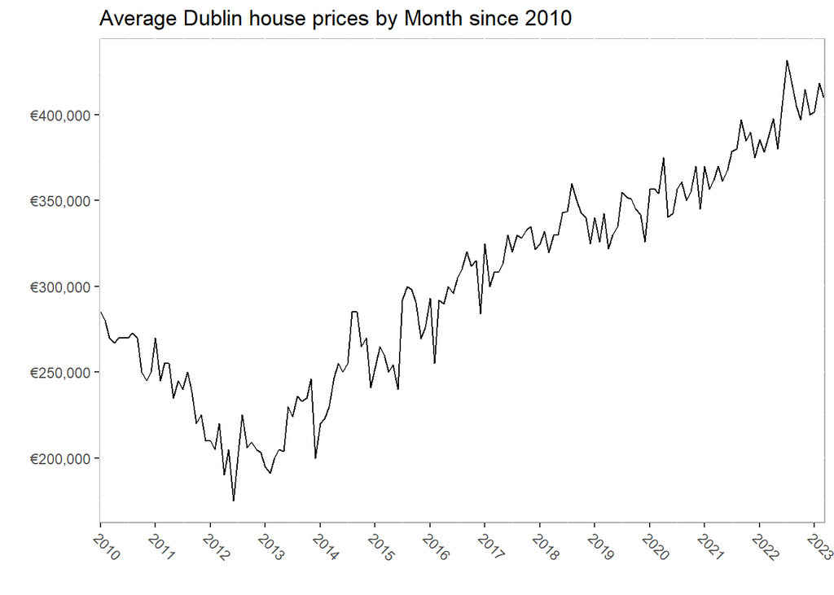

```r
  ggplot(DubByYearMonth, aes(YearMonth, Median)) +
  labs(x = "", y = "", title = "Average Dublin house prices by Month since 2010") +
  scale_y_continuous(labels=scales::dollar_format(prefix = "€"))+
  theme(axis.text.x=element_text(angle=-45, hjust=0.005)) +
  scale_x_date(expand = c(.002, .002), date_breaks = "1 year", date_labels = "%Y" ) +
  geom_line() +
    theme(panel.background = element_rect(fill = 'white', color = 'dark grey'))
```